The plot below compares the log2 fold changes in the two datasets considering the intersection of genes after the initial differential expression analysis. The black points that represent the genes can be generally fitted to the f(x) = x line which indicates a correlation between the two datasets.

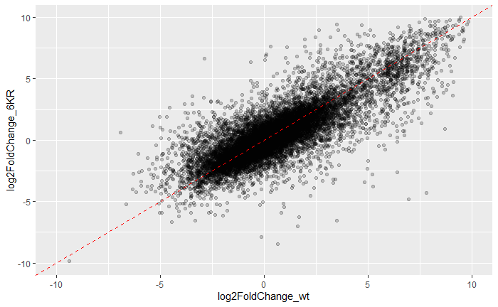

I used Spearman correlation to decipher the relationship between the two datasets.

```
Cannot compute exact p-value with ties

    Spearman's rank correlation rho

data:  filter1_shared_log2FC$log2FoldChange_wt and filter1_shared_log2FC$log2FoldChange_6KR
S = 2.353e+11, p-value < 2.2e-16
alternative hypothesis: true rho is not equal to 0
sample estimates:
      rho
0.8107402
```

The Spearman’s correlation coefficient is close to 1 with a low p-value indicating significant positive correlation between the two datasets.

The heatmap below shows all the differentially expressed genes in both datasets, comparing their change of magnitude. The log2 fold changes after the influenza A virus show great similarity.

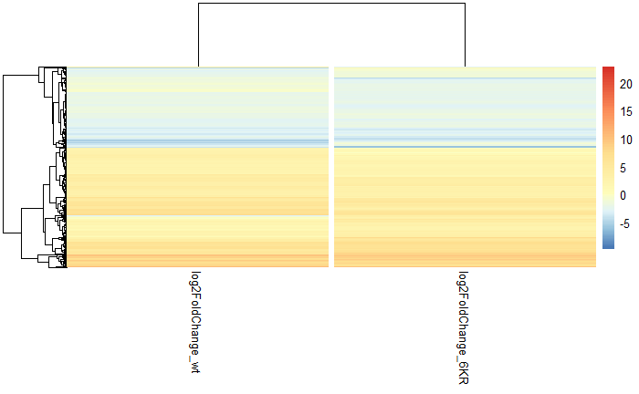

Based on the Venn-diagram below the number of genes that are differentially expressed in both datasets is 1379.

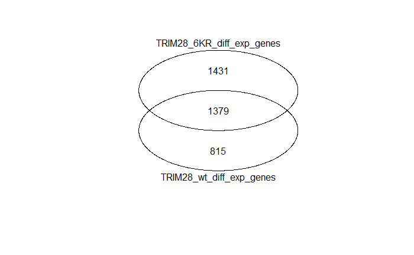

The full list of these genes with annotation is available on here

In conclusion the expectations were met with the outcome of the experiment as the samples with SUMOylation-deficient TRIM28 6KR showed greater anti-viral response after the infulenza A infection than the samples with the wild type TRIM28. The samples with the mutant gene resulted in significantly more differentially expressed genes, enriched KEGG pathways and biological processes specific to viral infection.